# Interplay between glycolytic and acetate metabolisms in *Escherichia coli*

This notebook performs computational analyses detailed in:

> From toxic waste to beneficial nutrient: acetate boosts *Escherichia coli* growth at low glycolytic flux.

> P. Millard, T. Gosselin-Monplaisir, S. Uttenweiler-Joseph, B. Enjalbert

> bioRxiv preprint, doi: 10.1101/2022.09.20.506926

This R Markdown notebook is available at https://github.com/MetaSys-LISBP/glucose_acetate_interplay

Author: Pierre Millard (pierre.millard@insa-toulouse.fr)

Copyright INRAE, 2023

## 1. Initialize environment

Load libraries and initialize environment.

```r
source("misc.R")
```

## 2. Simulate response of *E. coli* to changes of glycolytic activity and acetate concentration

### 2.1. Run simulations

Load the kinetic model detailed at doi: 10.7554/eLife.63661 and available from Biomodels database ([https://www.ebi.ac.uk/biomodels/)](https://www.ebi.ac.uk/biomodels/)) with the identifier MODEL2005050001.

```r
loadModel("model/Millard2020_Ecoli_glc_ace_kinetic_model.cps")
```

```
## # A COPASI model reference:
## Model name: "E. coli model - Glc-Ace metabolism"
## Number of compartments: 1
## Number of species: 6
## Number of reactions: 6
```

Delete events and fix concentrations of acetate, glucose and biomass.

```r
deleteEvent(getEvents()$key)
setSpecies(key="Ace_out", type="fixed")
setSpecies(key="Glc", type="fixed")
setSpecies(key="X", type="fixed")
```

Define the range of acetate concentration and glycolytic activity used to run simulations.

```r
#   number of steps
n_step <- 50

#   acetate concentration (between 0.1 and 100 mM)
ace_concentration <- 10**seq(-1, 2, length.out = n_step)

#   glycolytic activity (between 20 and 100 % of initial Vmax)
glc_vmax <- getParameters(key="(glc_upt).V")$value*seq(0.2*n_step, n_step)/n_step
```

Calculate steady-state fluxes for each acetate concentration and level of glycolytic activity.

```r
# create empty matrix to store simulation results
fluxes <- c("Values[v_growth_rate]", "Values[v_glc_uptake]", "Values[v_ace_net]")
simulation_results <- array(NA, dim=c(n_step*0.8+1, n_step, length(fluxes)+1), dimnames=list(inhibition=NULL, ace_concentration=NULL, specie=c("ace_concentration", fluxes)))

# run simulations

# for each glycolytic activity
for (k in seq(n_step*0.8+1)){

  # create empty matrix to store simulation results for a given glycolytic activity (k)
  res_ace_range <- matrix(NA, nrow=n_step, ncol=length(fluxes)+1, dimnames=list(r=NULL, c=c("ace_concentration", fluxes)))

  # update Vmax_glycolysis
  setParameters(key="(glc_upt).V", value = glc_vmax[k])
  applyInitialState()

  # for each acetate concentration
  for (j in seq(n_step)){

    # update acetate concentration
    setSpecies(key="Ace_out", initial_concentration=ace_concentration[j])
    applyInitialState()

    # calculate steady-state fluxes
    res_ss <- runSteadyState()

    # save steady-state fluxes for glycolytic activity k & acetate concentration j
    res_ace_range[j,] <- c(ace_concentration[j], unlist(res_ss$global_quantities[res_ss$global_quantities$key %in% fluxes, "value"]))
  }

  # save steady-state fluxes for all acetate concentrations at glycolytic activity k
  simulation_results[k,,] <- res_ace_range

}
```

### 2.2. Glycolytic flux

Save results as Source data.

```r
data_to_save <- simulation_results[,,"Values[v_glc_uptake]"]
colnames(data_to_save) <- ace_concentration
rownames(data_to_save) <- glc_vmax*0.00177
write.csv(data_to_save, "results/SourceData/Figure 1/1B/data_1B.csv", quote=FALSE)
```

Plot.

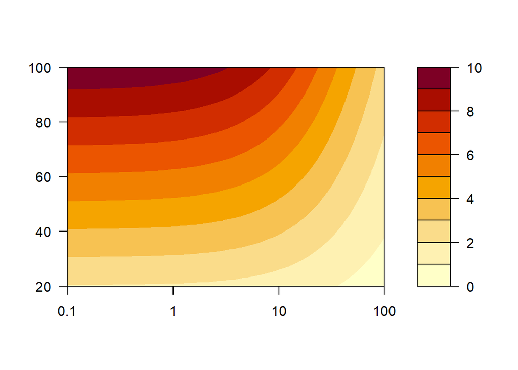

```r
filled.contour(x=log10(ace_concentration), y=(glc_vmax/max(glc_vmax))*100, z = t(simulation_results[,,3]), nlevels = 10,
                 plot.axes = { axis(1, at=c(-1, 0, 1, 2), label=c(0.1, 1, 10, 100));
                 axis(2)})
```

### 2.3. Acetate flux

Save results as Source data.

```r
data_to_save <- simulation_results[,,"Values[v_ace_net]"]
colnames(data_to_save) <- ace_concentration
rownames(data_to_save) <- glc_vmax*0.00177
write.csv(data_to_save, "results/SourceData/Figure 1/1C/data_1C.csv", quote=FALSE)
```

Plot.

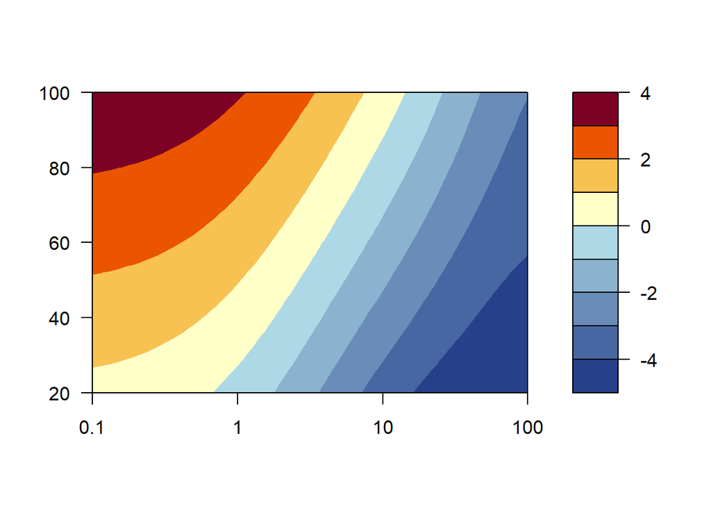

```r
cols = colorRampPalette(c('royalblue4','lightblue'))
  color.palette = function(n) hcl.colors(n, "YlOrRd", rev = TRUE)

  filled.contour(x=log10(ace_concentration), y=(glc_vmax/max(glc_vmax))*100, z = t(simulation_results[,,4]), nlevels = 10,
                 col = c(cols(5), color.palette(4)),
                 plot.axes = { axis(1, at=c(-1, 0, 1, 2), label=c(0.1, 1, 10, 100));
                 axis(2)})
```

### 2.4. Growth rate

Save results as Source data.

```r
data_to_save <- simulation_results[,,"Values[v_growth_rate]"]
colnames(data_to_save) <- ace_concentration
rownames(data_to_save) <- glc_vmax*0.00177
write.csv(data_to_save, "results/SourceData/Figure 1/1D/data_1D.csv", quote=FALSE)
```

Plot.

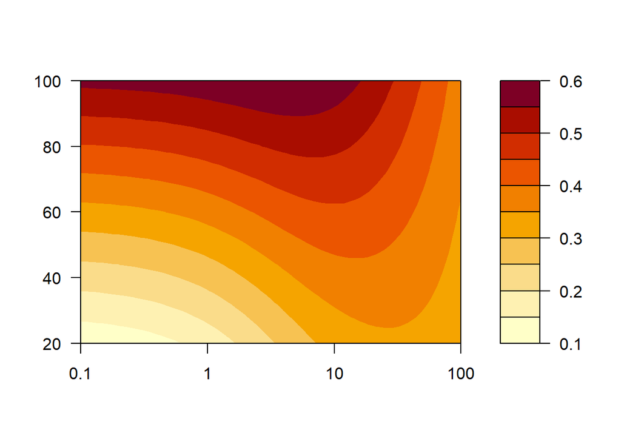

```r
filled.contour(x=log10(ace_concentration), y=(glc_vmax/max(glc_vmax))*100, z = t(simulation_results[,,2]), nlevels = 10,
                 plot.axes = { axis(1, at=c(-1, 0, 1, 2), label=c(0.1, 1, 10, 100));
                 axis(2)})
```

## 3. Run sensitivity analysis

```r
loadModel("model/Millard2020_Ecoli_glc_ace_model_4_MC.cps")
```

```
## # A COPASI model reference:
## Model name: "E. coli model - Glc-Ace metabolism"
## Number of compartments: 1
## Number of species: 14
## Number of reactions: 16
```

```r
# create calibration data files for monte carlo simulations
file.copy("model/data_1mM.txt", "model/data_1mM_MC.txt", overwrite=TRUE)
```

```
## [1] TRUE
```

```r
file.copy("model/data_10mM.txt", "model/data_10mM_MC.txt", overwrite=TRUE)
```

```
## [1] TRUE
```

```r
file.copy("model/data_30mM.txt", "model/data_30mM_MC.txt", overwrite=TRUE)
```

```
## [1] TRUE
```

```r
# number of Monte Carlo iterations
n_iter_mc <- 5

# get parameters for the best fit
res_PE_model4 <- runParameterEstimation(method = "Statistics", model = getCurrentModel())

# list used to set up global sensitivity analysis and store calculation results
fit_results <- list("1" = list("initial_concentrations"= c("Ace0_out"=0.92, "Glc"=12.9, "X"=0.0671),
                               "species_idx" = c("[Ace0_out]_0"=1, "[Glc]_0"=1, "[X]_0"=1),
                               "data_exp" = read.table("model/data_1mM.txt", header=TRUE, sep="\t"),
                               "sd" = c("Ace"=0.2, "Glc"=0.5, "X"=0.045, "Ace_enr"=0.03),
                               "mapping" = c("Ace"="Acet_out", "Glc"="Glc", "X"="X", "Ace_enr"="Values[Ace_enr]")),
                    "10" = list("initial_concentrations"= c("Ace0_out"=9, "Glc"=14.192, "X"=0.07),
                                "species_idx" = c("[Ace0_out]_0"=2, "[Glc]_0"=2, "[X]_0"=2),
                                "data_exp" = read.table("model/data_10mM.txt", header=TRUE, sep="\t"),
                                "sd" = c("Ace"=0.2, "Glc"=0.5, "X"=0.045, "Ace_enr"=0.03),
                                "mapping" = c("Ace"="Acet_out", "Glc"="Glc", "X"="X", "Ace_enr"="Values[Ace_enr]")),
                    "30" = list("initial_concentrations"= c("Ace0_out"=30.2448, "Glc"=12.5, "X"=0.07227),
                                "species_idx" = c("[Ace0_out]_0"=3, "[Glc]_0"=3, "[X]_0"=3),
                                "data_exp" = read.table("model/data_30mM.txt", header=TRUE, sep="\t"),
                                "sd" = c("Ace"=0.2, "Glc"=0.5, "X"=0.045, "Ace_enr"=0.03),
                                "mapping" = c("Ace"="Acet_out", "Glc"="Glc", "X"="X", "Ace_enr"="Values[Ace_enr]")),
                    "res_par" = res_PE_model4$parameters[, c("parameter", "value")],
                    "res_cost" = c(res_PE_model4$main$objective_value),
                    "res_converged" = c(test_khi2(nb_points=152, k_val=res_PE_model4$main$objective_value, nb_par=11)$`p-value, i.e. P(X^2<=value)` < 0.95))
```

Simulate data from the best fit.

```r
# simulate data for the best fit
for (i in c("1", "10", "30")){
  # update initial conditions (Glc, Ace and biomass concentrations)
  for (j in names(fit_results[[i]][["initial_concentrations"]])){
    setSpecies(key=j, initial_concentration=fit_results[[i]][["initial_concentrations"]][j])
  }
  # apply initial state
  applyInitialState()
  # run time course simulation
  tmp <- as.matrix(runTimeCourse()$result)
  # get complete simulation results
  idx_t_max <- (tmp[,"Time"] <= max(fit_results[[i]][["data_exp"]]$time))
  fit_results[[i]]$simulations <- array(NA, dim=c(n_iter_mc+1, sum(idx_t_max), ncol(tmp)), dimnames=list(iter=NULL, time=NULL, specie=colnames(tmp)))
  fit_results[[i]]$simulations[1,,] <- tmp[idx_t_max,]
  # get index of simulated data at experimental time points
  fit_results[[i]]$t_idx <- match(fit_results[[i]][["data_exp"]]$time, fit_results[[i]]$simulations[1,,"Time"])
  # get simulated data that match experimental time points
  sim_data <- fit_results[[i]][["data_exp"]]
  for (k in names(fit_results[[i]][["mapping"]])){
    sim_data[,k] <- fit_results[[i]]$simulations[1,fit_results[[i]]$t_idx,fit_results[[i]][["mapping"]][[k]]]
  }
  fit_results[[i]]$sim_mc <- sim_data
}
```

Run sensitivity analysis.

Delete temporary (noisy) calibration data files.

Save global sensitivity analysis results for further use.

## 4. Glycolytic control of the acetate flux, in absence or presence of acetate

### 4.1. Load experimental data

```r
exp_data <- read.table("data/data_E_coli_K12_MG1655_Figure_2.txt", header=TRUE, sep="\t")
```

Calculate the total carbon uptake rate and the contribution of acetate to carbon uptake.

```r
# calculate total carbon uptake flux
Ctotal <- -exp_data$qACE*2 + exp_data$qGLC*6

# calculate the contribution of acetate to carbon uptake (qACE/(qGLC+qACE))
contribution_acetate <- -exp_data$qACE*2 / (-exp_data$qACE*2 + exp_data$qGLC*6) * 100

# add calculated metrics to measurements dataframe
exp_data <- cbind(exp_data, Ctotal, contribution_acetate)

# create mask for data obtained at low acetate concentration (< 2 mM)
filter <- (exp_data$ACE<2)
```

### 4.2. Run simulations

Simulate data at 0.1 and 30 mM acetate concentration (with sensitivity analysis).

```r
load(file="results/MonteCarloSimulations/mc_results.RData")
```

```r
# load model
loadModel("model/Millard2020_Ecoli_glc_ace_kinetic_model_sensitivity_analysis.cps")
```

```
## # A COPASI model reference:
## Model name: "E. coli model - Glc-Ace metabolism"
## Number of compartments: 1
## Number of species: 6
## Number of reactions: 6
```

```r
# remove events and fix concentrations of actate, glucose and biomass
deleteEvent(getEvents()$key)
setSpecies(key="Ace_out", type="fixed")
setSpecies(key="Glc", type="fixed")
setSpecies(key="X", type="fixed")
```

Simulate steady-state fluxes for all set of estimated parameters.

Save simulation results for further use.